# Monte Carlo Simulation

Jay Kim

September 17, 2020

probability-and-inference-portfolio-Kim-Jay

# 1 Introduction

Welcome to a game of roulette. The Martingale system is supposedly the most popular strategy in the game and the concept is quite simple: increase bets after each loss so that when you eventually score a win, you get the lost money back. Here, with the help of simulations, we will see exactly how effective and profitable the Martingale strategy really is. We will examine this strategy with various parameters and by changing some as well.

# 2 Methods

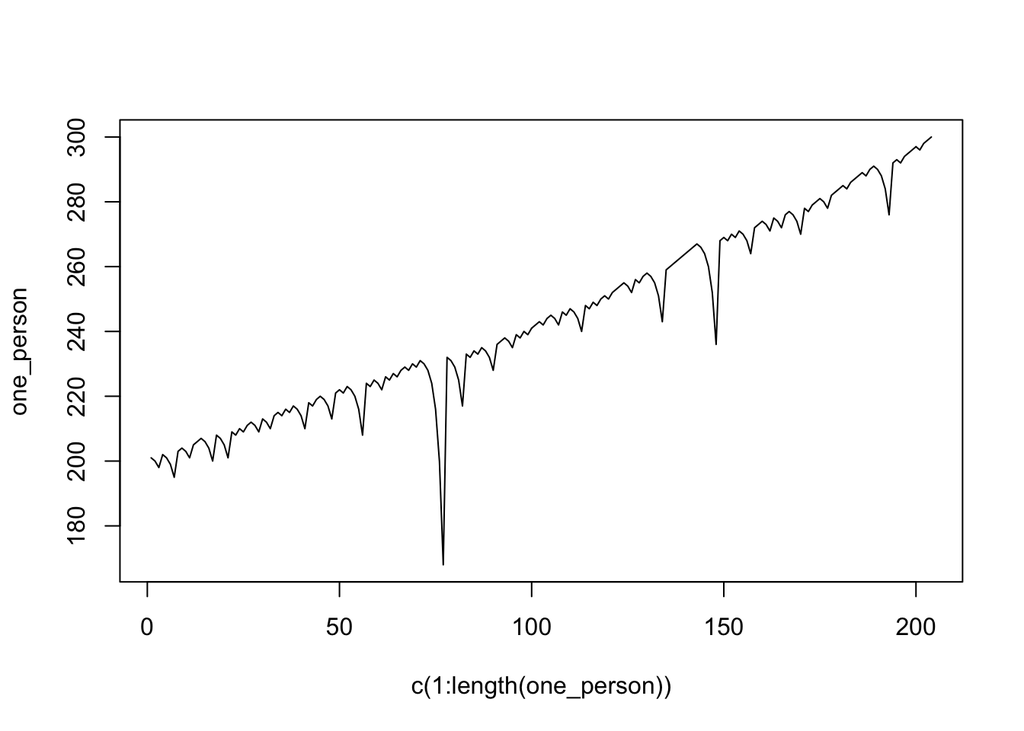

```r
library(dplyr)
library(tidyverse)
#' A single play of the Martingale strategy
#'
#' Takes a state list, spins the roulette wheel, returns the state list with updated values (for example, budget, plays, etc)
#' @param state A list with the following entries:
#'   B              number, the budget
#'   W              number, the budget threshold for successfully stopping
#'   L              number, the maximum number of plays
#'   M              number, the casino wager limit
#'   plays          integer, the number of plays executed
#'   previous_wager number, the wager in the previous play (0 at first play)
#'   previous_win   TRUE/FALSE, indicator if the previous play was a win (TRUE at first play)
#' @return The updated state list
one_play <- function(state){
    # Wager
    proposed_wager <- ifelse(state$previous_win, 1, 2*state$previous_wager)
    wager <- min(proposed_wager, state$M, state$B)
    # Spin of the wheel
    red <- rbinom(1,1,18/38)
    # Update state
    state$plays <- state$plays + 1
    state$previous_wager <- wager
    if(red){
      # WIN
      state$B <- state$B + wager
      state$previous_win <- TRUE
    }else{
      # LOSE
      state$B <- state$B - wager
      state$previous_win <- FALSE
    }
  state
}
#' Stopping rule
#'
#' Takes the state list and determines if the gambler has to stop
#' @param state A list.  See one_play
#' @return TRUE/FALSE
stop_play <- function(state){
  if(state$B <= 0) return(TRUE)
  if(state$plays >= state$L) return(TRUE)
  if(state$B >= state$W) return(TRUE)
  FALSE
}
#' Play roulette to either bankruptcy, success, or play limits
#'
#' @param B number, the starting budget
#' @param W number, the budget threshold for successfully stoping
#' @param L number, the maximum number of plays
#' @param M number, the casino wager limit
#' @return A vector of budget values calculated after each play.
one_series <- function(
    B = 200
  , W = 300
  , L = 1000
  , M = 100
){
  # initial state
  state <- list(
    B = B
  , W = W
  , L = L
  , M = M
  , plays = 0
  , previous_wager = 0
  , previous_win = TRUE
  )
  # vector to store budget over series of plays
  budget <- rep(NA, L)
  # For loop of plays
  for(i in 1:L){
    new_state <- state %>% one_play
    budget[i] <- new_state$B
    if(new_state %>% stop_play){
      return(budget[1:i])
    }
    state <- new_state
  }
  budget
}
# helper function
get_last <- function(x) x[length(x)]
one_person= one_series(B = 200, W = 300, L = 1000, M = 100)
plot(c(1:length(one_person)), one_person, type="l")
```

# 3 Results

Default parameters ‘(B = 200, W = 300, L = 1000, M = 100)’ Here, we see the percentage of people who walked out with varying amounts of wages. And in the next illustration we see how changing one of the parameters changes the outcome.

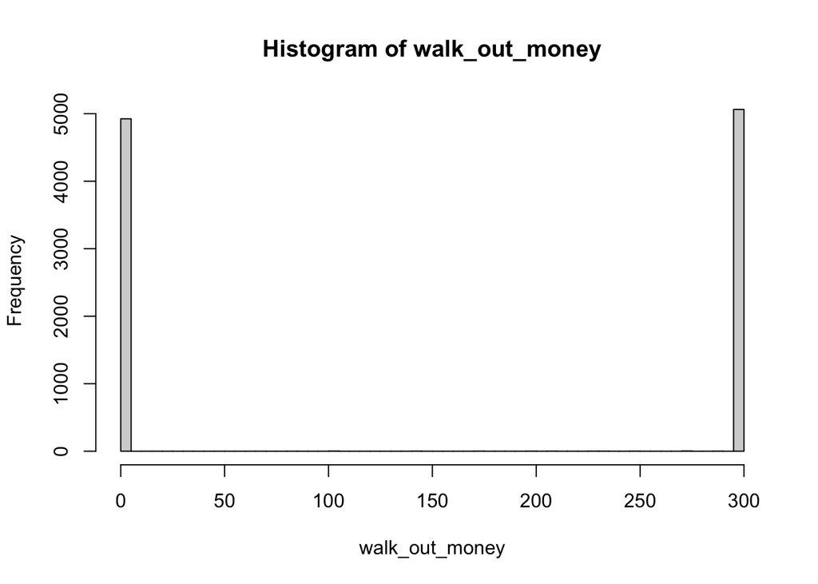

```r
# Simulation
walk_out_money <- rep(NA, 10000)
for(j in seq_along(walk_out_money)){
  walk_out_money[j] <- one_series(B = 200, W = 300, L = 1000, M = 100) %>% get_last()
}
# Walk out money distribution
hist(walk_out_money, breaks = 100)
```

```r
# Estimated probability of walking out with extra cash
mean(walk_out_money > 200)
```

```
## [1] 0.5071
```

```r
# Estimated earnings
mean(walk_out_money - 200)
```

```
## [1] -47.8359
```

The function is called Walk_out_money and it consists of a for loop that starts with the starting budget and is repeated 10,000 times. The outcomes are graphed and it takes the parameters B, W, L, and M. the get_last function gets the last value of each simulation-which is how much the player ends the game with. Mean(walk_out_money) is how much money on average someone walks out with, but if we care about profit rather than gross earnings (how much money on top of your starting money you walked out with, or how much you lost), then mean(walk_out_money - 200) will get you the average of your earnings minus that starting budget.

The estimated probability of walking out with extra cash is 0.5071. The estimated earnings would be on average -47.8359.

Here, we changed one of the parameters. After changing the starting budget, which is represented by the parameter ‘B’ from 200 to 100. With this change we can see that the frequency that the player walks out with 0 dollars is higher, than had they started off with more money.

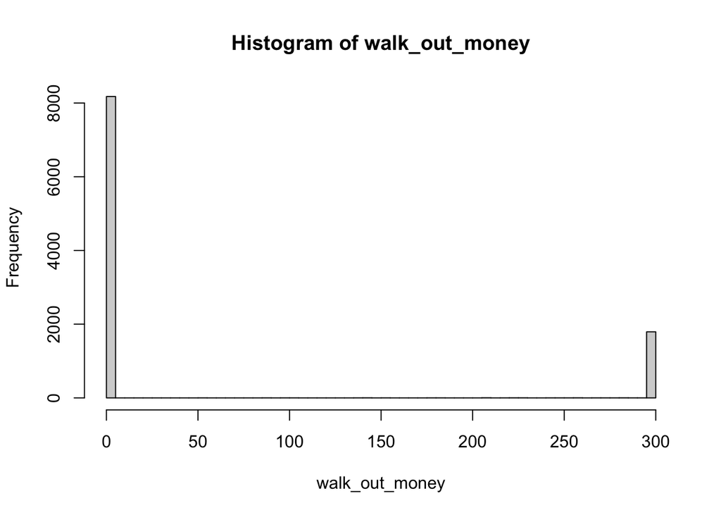

```r
# Simulation
# Changed 10000 to 10
walk_out_money <- rep(NA, 10000)
for(j in seq_along(walk_out_money)){
  walk_out_money[j] <- one_series(B = 100, W = 300, L = 1000, M = 100) %>% get_last
}

# Walk out money distribution
hist(walk_out_money, breaks = 100)
```

```r
# Estimated probability of walking out with extra cash
mean(walk_out_money > 200)
```

```
## [1] 0.1813
```

```r
# Estimated earnings
mean(walk_out_money - 200)
```

```
## [1] -145.586
```

Here, I changed ‘get_last’, that gives us last dollar amount they left with, to ‘length’, which finds the average number of times they played and then plots it on the x axis.

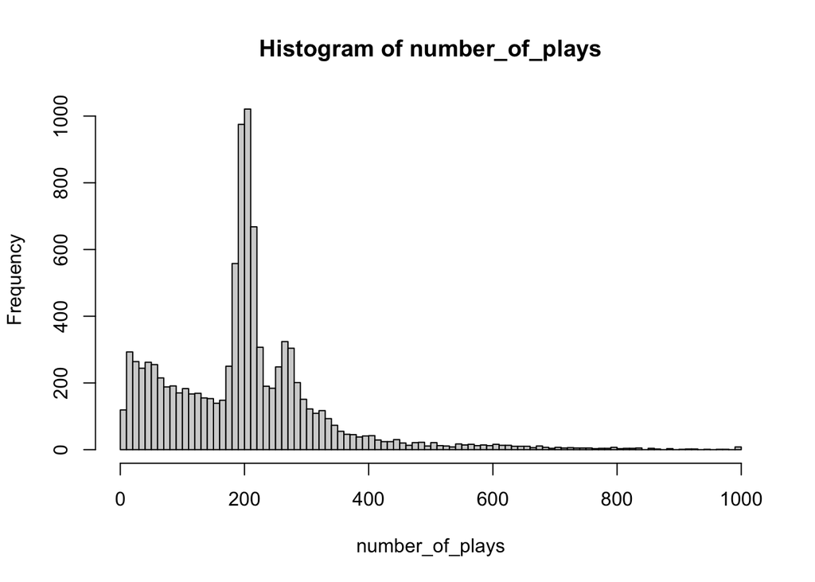

```r
# Simulation
# Changed 10000 to 20
number_of_plays <- rep(NA, 10000)
for(j in seq_along(number_of_plays)){
  number_of_plays[j] <- one_series(B = 200, W = 300, L = 1000, M = 100) %>% length
}
#  Number of plays distribution
hist(number_of_plays, breaks = 100)
```

```r
#Average number of plays
mean(number_of_plays)
```

```
## [1] 201.1047
```

# 4 Conclusions

There are a few limitations with this simulation. First, this may not be too applicable in real life. We may need to add a few more parameters to improve its accuracy such as differing amounts of ending budget, as it could then more accurately replicate real-life. Another could be the starting budget, since how much money a player starts out with can change the graphs we were examining. We could even have multiple simulations with varying levels of starting budget to see the differences. After running all the simulations and comparing different outcomes based on different parameters, we can see that despite the Martingale Strategy, gambling will eventually lead to big losses.